# Factor Analysis of Likert-type Questions in the Survey for the Revision of the SAA’s Principles of Archaeological Ethics

09 July, 2020

A factor analysis is a model of the measurement of one or more latent variables. This latent variable cannot be directly measured with a single variable (e.g. intelligence, social anxiety, soil health). Instead, it is seen through the relationships it causes in a set of outcome variables.

We focus on the questions about the nine Principles and the Likert-type responses.

### 0.0.1 Testing the assumptions for Factor Analysis

We assume that there are at least some correlations among the variables so that coherent factors can be identified. There should be some degree of collinearity among the variables but not an extreme degree or singularity among the variables.

We explore our data to see if they are suitable for factor analysis. These tests check to see whether our matrix is significantly different from an identity matrix.

```
## # Is the data suitable for Factor Analysis?
##
##   - KMO: The Kaiser, Meyer, Olkin (KMO) measure of sampling adequacy suggests that data seems appropriate for factor analysis (KMO = 0.93).
##   - Sphericity: Bartlett's test of sphericity suggests that there is sufficient significant correlation in the data for factor analaysis (Chisq(36) = 4060.92, p < .001).
```

We explore the structure in the data using a hierarchical cluster analysis where distances are calculated using polychoric correlation. This is a correlation method for ordinal responses such as likert-type data where we don’t know the exact distances between each measurement unit. For example, is the difference between “Strongly Agree” and “Agree” the same is the difference between “Disagree” and “Strongly Disagree”? Are these distances the same for each person? We don’t know.

### 0.0.2 Correlations

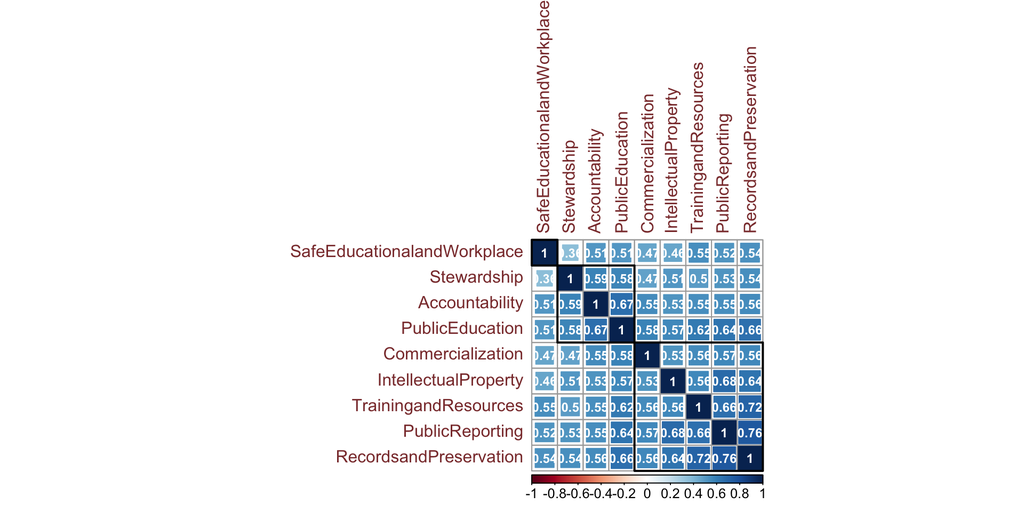

### 0.0.3 Hierarchical Cluster Analysis

We computed a hierarchical cluster analysis on the correlations to see which questions tend to be similar in how people responded. For example, we can see that responses to questions about the principles on public education and accountability are closely correlated.

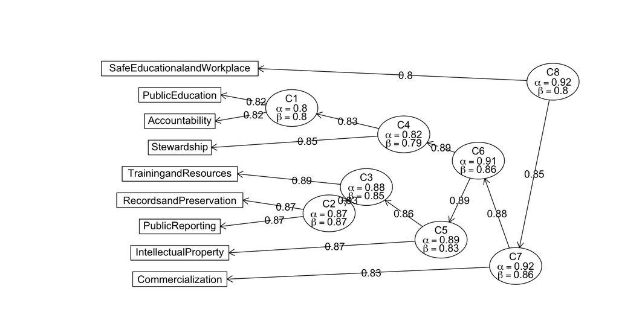

### 0.0.4 Optimum number of latent factors

Next we can explore to find the optimum number of factors to group the correlated questions into. To do this need to identify how many latent factors are present in our data.

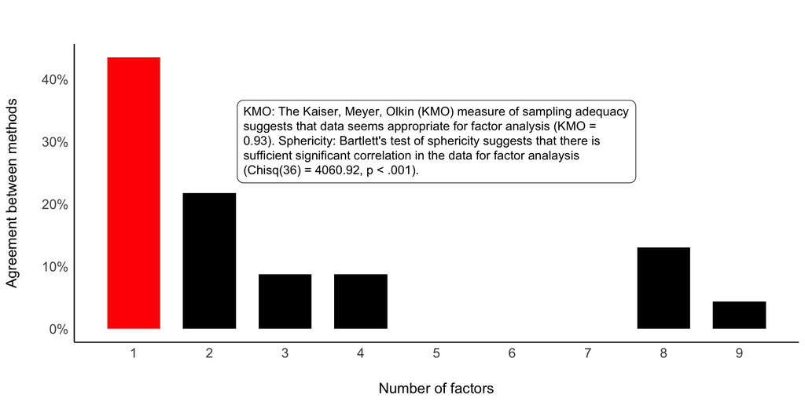

After exploring, we can confirm the optimum number of latent factors using Confirmatory Factor Analysis (CFA). This allows us to evaluate several models of our data using different numbers of latent factors. This will help us make a good choice the best number of factors to extract.

### 0.0.5 Exploratory Factor Analysis

The plot on the left shows a path diagram representation. The square boxes are the observed variables, and the ovals are the unobserved, latent factors. The straight arrows are the loadings, the correlation between the factor and the observed variable(s). This helps us to identify which item belong in which factor, and the strength of its contribution.

Factor loading can be classified based on their magnitude. * 0.50 or more - Practically significant * 0.40 to 0.49 - More important * 0.30 to 0.39 - Minimum consideration level

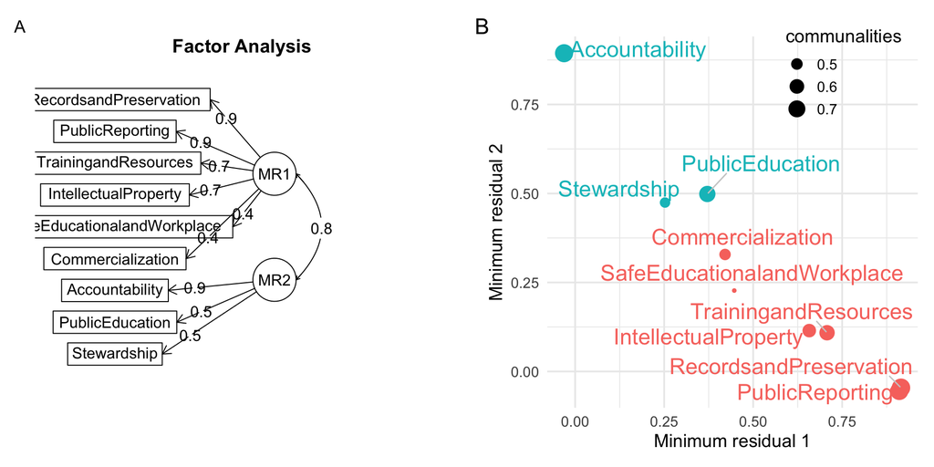